# Project 2 – Regression Battleship

## Step 1. Creating your Data

There are only three general rules that you must follow in the creation of your dataset.

1. Your dataset must have one “Y” variable and 20 “X” variables labeled as “Y”, “X1”, …, “X20”.
2. Your response variable $Y$ must come from a linear regression model that satisfies:
   $$Y_i^\prime = \beta_0 + \beta_1 X_{i1}^\prime + \ldots + \beta_{p-1}X_{i,p-1}^\prime + \epsilon_i$$
   where $\epsilon_i \sim N(0,\sigma^2)$ and $p\leq 21$.
3. All $X$-variables that were used to create $Y$ are contained in your dataset.

### Brother Saunders’s True Model:

$$Y_i = \beta_0 + \beta_1 X_8 + \beta_2 X_{15} + \beta_3 X_6 + \beta_4 X_8 X_{15} + \beta_5 X_8 X_6 + \beta_6 X_{15} X_6 + \beta_7 X_8 X_{15} X_6 + \epsilon_i$$

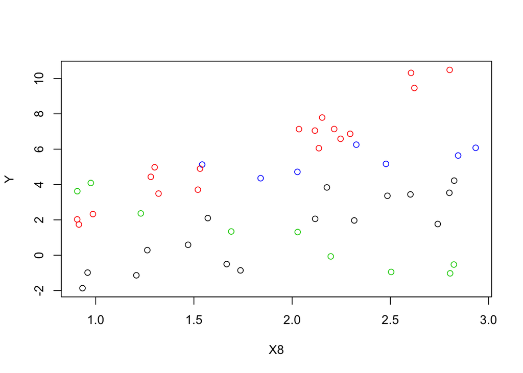

```r
plot(Y ~ X8, data=yourData, col=interaction(X6,X15))
```

## Step 2. Analyzing Brother Saunders’s Data

Brother Saunders followed the same 3 rules that were outlined above in the creation of his data. You need to analyze his data to try to make a guess at his true regression model. Document your approach as best you can and state your final predictions here.

The original model used to create $Y_i$ was:

`Y <- beta0 + beta1*X1 + beta2*X2 + beta3*X3 + beta4*X1*X2 + beta5*X1*X3 + beta6*X2*X3 + beta7*X1*X2*X3 + errors`

Then, since

- $X_1$ became $X_8$,
- $X_2$ became $X_{15}$, and
- $X_3$ became $X_6$,

the model you should have found was:

$$Y_i = \beta_0 + \beta_1 X_8 + \beta_2 X_{15} + \beta_3 X_6 + \beta_4 X_8 X_{15} + \beta_5 X_8 X_6 + \beta_6 X_{15} X_6 + \beta_7 X_8 X_{15} X_6 + \epsilon_i$$

where $\epsilon_i \sim N(0,\sigma^2)$, and the coefficients were as follows.

| Coefficient | Value |
| --- | --- |
| $\beta_0$ | -3.14 |
| $\beta_1$ | 2.4 |
| $\beta_2$ | 8.28 |
| $\beta_3$ | 1.7 |
| $\beta_4$ | -4.8 |
| $\beta_5$ | 1.8 |
| $\beta_6$ | -2.8 |
| $\beta_7$ | 1.1 |
| $\sigma$ | 0.75 |

### Everyone’s Guesses

```r
guesses <- read.csv("Guesses.csv", header=TRUE, stringsAsFactors = FALSE)
tmp <- strsplit(guesses$Name, " - ")
guesses$Name <- sapply(tmp, function(x) x[2])
guesses$Date <- sapply(tmp, function(x) x[3])
guesses$Model[12] <- "\\left|Y_i\\right| = 0.6417 + 0.7415 X_8 +  2.034 X_8X_6 - 0.007473 X_8X_{16} + \\epsilon_i"
pander::pander(cbind(Name=guesses$Name, Guess=paste("$$",guesses$Model,"$$"), Correct=guesses$Correct), split.tables=Inf)
```

[output not shown]